# predictR

Wesley Chioh

April 19, 2020

## Data Processing

Relevant time scale: Monthly  
Datasets: Electricity generation, Rigs count, GDP, OECD Business Tendency Survey, Percentage of Civilian Workforce Unemployed >15 weeks

```r
gdp_complete <- gdp %>%
  mutate(date = as.yearmon(substr((Date), 1, 7)),
         `GDP (Continuously Compounding)` = `GDP (Continuously Compounding)`*100,
         `GDP (YoY % Change)` = `GDP (YoY % Change)`*100,
         gdp_change_lagged = lag(`GDP (Continuously Compounding)`, 1)) %>%
  filter(date >= "Jan 1973") %>%
  select(date, `GDP (YoY % Change)`, `GDP (Continuously Compounding)`, gdp_change_lagged)
electricity_complete <- electricity %>%
  mutate(date = as.yearmon(date),
         rate_generated_change = (value - lag(value,1))/lag(value,1),
         rate_generated_change_secondorder = (rate_generated_change - lag(rate_generated_change,1))/lag(rate_generated_change,1)) %>%
  select(date, rate_generated_change, rate_generated_change_secondorder)
rigs_complete <- rigs %>%
  mutate(date = as.yearmon(substr(date, 1, 7))) %>%
  select(date, change_first_order, change_second_order)
colnames(rigs_complete)[2:3] <- c("rigs_change_first_order", "rigs_change_second_order")
business_sentiment <- business_sentiment %>%
  mutate(date = as.yearmon(substr(date, 1, 7)),
         sentiment_change_first_order = (value - lag(value,1))/lag(value,1)) %>%
  select(date, value, distance_peak, sentiment_change_first_order)
colnames(business_sentiment)[2] <- "business_sentiment"
sentiment_period <- rep(0, dim(business_sentiment)[1])
for (i in 2:dim(business_sentiment)[1]){
  sentiment_i = business_sentiment$sentiment_change_first_order[i]
  #print(sentiment_i)
  sentiment_h = business_sentiment$sentiment_change_first_order[i-1]
  #print(sentiment_h)
  sentiment_h[is.na(sentiment_h)] <- 0
  if(sign(sentiment_i) == sign(sentiment_h)){
    sentiment_period[i] = sentiment_period[i-1]+1
  }
  else{
    sentiment_period[i] = 1
  }
}
business_sentiment$sentiment_period <- sentiment_period

LT_unemployed_complete <- LT_unemployed %>%
  mutate(date = as.yearmon(substr(date, 1, 7)),
         rate_change_first_order = (value - lag(value,1))/lag(value,1)) %>%
  select(date, value, rate_change_first_order)
colnames(LT_unemployed_complete)[2] <- "LT_unemployment"
rate_change_period <- rep(0, dim(LT_unemployed_complete)[1])
threshold_period <- rep(0, dim(LT_unemployed_complete)[1])
for (i in 2:dim(LT_unemployed_complete)[1]){
  sentiment_i = LT_unemployed_complete$rate_change_first_order[i]
  #print(sentiment_i)
  sentiment_h = LT_unemployed_complete$rate_change_first_order[i-1]
  #print(sentiment_h)
  sentiment_h[is.na(sentiment_h)] <- 0
  if(sign(sentiment_i) == sign(sentiment_h)|sign(sentiment_i)==0){
    rate_change_period[i] = rate_change_period[i-1]+1
  }
  else{
   rate_change_period[i] = 1
  }
  if(LT_unemployed_complete$LT_unemployment[i] <= 1.5){
    threshold_period[i] = threshold_period[i-1]+1
  }
}
LT_unemployed_complete$threshold_period <- threshold_period
LT_unemployed_complete$rate_change_period <- rate_change_period

# inner join all together and to get recession dates
econ_situation_nber_df <- inner_join(gdp_complete, electricity_complete, by = "date")
econ_situation_nber_df <- inner_join(econ_situation_nber_df, rigs_complete, by = "date")
econ_situation_nber_df <- inner_join(econ_situation_nber_df, business_sentiment, by = "date")
econ_situation_nber_df <- inner_join(econ_situation_nber_df, LT_unemployed_complete, by = "date")
NBER_recession_months <- econ_situation_nber_df$date %>%
  .[c(11:27, 85:90, 103:119, 211:219, 339:347, 420:438)]
econ_situation_nber_df <- econ_situation_nber_df %>%
  mutate(NBER_recession = ifelse(date %in% NBER_recession_months, "Y", "N"),
         NBER_recession_next = as.factor(lead(NBER_recession,1)),
         NBER_recession_two = as.factor(lead(NBER_recession,2))) %>%
  as.data.frame() %>%
  drop_na()

DT::datatable(econ_situation_nber_df)
```

|  | date | GDP (YoY % Change) | GDP (Continuously Compounding) | gdp_change_lagged | rate_generated_change | rate_generated_change_secondorder | rigs_change_first_order | rigs_change_second_order | business_sentiment | distance_peak | sentiment_change_first_order | sentiment_period | LT_unemployment | rate_change_first_order | threshold_period | rate_change_period | NBER_recession | NBER_recession_next | NBER_recession_two |
| --- | --- | --- | --- | --- | --- | --- | --- | --- | --- | --- | --- | --- | --- | --- | --- | --- | --- | --- | --- |
| 2 | 1973.08333333333 | 7.56189413062283 | 9.69927321073882 | 9.77830905374191 | -0.0311806278646263 | -1.50793814192341 | 0.0734 | 0.301418439716312 | 103.598211096571 | 0.0134486967518545 | -0.00147008687439374 | 1 | 1 | -0.090909090909091 | 1 | 1 | N | N | N |
| 3 | 1973.16666666667 | 7.14159992376864 | 4.34672393198738 | 9.69927321073882 | 0.0613866636330057 | -2.15916746029345 | 0.0564 | -2.11242603550296 | 103.34550523695 | 0.0144972562868482 | -0.00243928786941541 | 2 | 1 | 0 | 2 | 2 | N | N | N |
| 4 | 1973.25 | 6.72757069576086 | 4.33103573433442 | 4.34672393198738 | -0.0529575455969626 | -0.383396152082584 | -0.0507 | -0.212732919254658 | 102.96212838896 | 0.0122934776544077 | -0.00370966155819746 | 3 | 0.9 | -0.1 | 3 | 1 | N | N | N |
| 5 | 1973.33333333333 | 6.31966740260333 | 4.31546037324821 | 4.33103573433442 | -0.0858858500086029 | 0.194716081374859 | -0.0644 | 0.957446808510638 | 102.49747493311 | 0.00421589213305604 | -0.00451285791310254 | 4 | 0.9 | 0 | 4 | 2 | N | N | N |
| 6 | 1973.41666666667 | 5.80023215941828 | -2.10545640317292 | 4.31546037324821 | -0.0718880839954602 | 2.51024312453824 | -0.0329 | -0.390740740740741 | 102.067170750898 | -0.00419819300419659 | -0.00419819300419659 | 5 | 0.9 | 0 | 5 | 3 | N | N | N |
| 7 | 1973.5 | 5.28404678822279 | -2.10915701925103 | -2.10545640317292 | -0.0204795170718886 | -1.15679223235608 | -0.054 | 0.551724137931035 | 101.711737417823 | -0.012144183407062 | -0.00348234726660993 | 6 | 0.8 | -0.111111111111111 | 6 | 1 | N | N | N |
| 8 | 1973.58333333333 | 4.77108088465561 | -2.11287066687191 | -2.10915701925103 | 0.130615635507884 | 6.52198078975283 | -0.0348 | -0.317647058823529 | 101.868688748557 | -0.0142900892013345 | 0.0015430994958749 | 1 | 0.9 | 0.125 | 7 | 1 | N | N | N |
| 9 | 1973.66666666667 | 4.51920758093796 | 3.79090749267945 | -2.11287066687191 | 0.0173645265999377 | -0.575511525778296 | -0.051 | 0.265508684863523 | 102.223439063672 | -0.0132702294600192 | 0.0034824274217432 | 2 | 0.9 | 0 | 8 | 2 | N | N | Y |
| 10 | 1973.75 | 4.27011491734122 | 3.77896938000504 | 3.79090749267945 | 0.0409069448393751 | -2.14929930084877 | -0.0403 | 2.76635514018692 | 102.576264751282 | -0.0113201024738836 | 0.00345151455323498 | 3 | 0.9 | 0 | 9 | 3 | N | Y | Y |
| 11 | 1973.83333333333 | 4.02375709992526 | 3.76710622101228 | 3.77896938000504 | -0.0355929432908947 | 0.419765134874716 | -0.0107 | -1.44398340248963 | 102.654723403742 | 0 | 0.000764881160863479 | 4 | 0.9 | 0 | 10 | 4 | Y | Y | Y |

[output cut: 550 more lines]

## Models

So I created multiple random forest and stochastic gradient boosting models and asked them a very simple question: Will there be a recession the following month or not, given the data?  
The model was trained and tested on a 70:30 randomly sampled split.

### Random Forest and Stochastic Gradient Boosting 1A1

These model does **NOT** include GDP growth data. It is a one-month forecast of whether the economy will be in a recession as defined by NBER.

```r
# creating test-train data
testIDs <- createDataPartition(econ_situation_nber_df$NBER_recession_next, p = 0.7, list = F)
train_x <- econ_situation_nber_df[testIDs,c(5:16)]
train_y <- econ_situation_nber_df$NBER_recession_next[testIDs]
test_x <- econ_situation_nber_df[-testIDs, c(5:16)]
test_y <- econ_situation_nber_df$NBER_recession_next[-testIDs]

# model tuning
trctrl <- trainControl(method = "repeatedcv",
                       number = 10, repeats = 5, search = "grid")
mtry <- ncol(train_x)
ntrees <- 71
tunegrid <- expand.grid(.mtry = c(2:mtry))
metric = "Accuracy"
# following can be commented out if loading a pretrained model from file
# parallel processing to speed things up
# random forest model
cl <- makePSOCKcluster(5)
registerDoParallel(cl)
rf_recession <- train(x = train_x, y = train_y, method = "rf", metric = metric, trControl = trctrl, tuneGrid = tunegrid)
stopCluster(cl)
saveRDS(rf_recession, "./models/rf_1mth_woGDP.RDS")
rf_recession <- readRDS("./models/rf_1mth_woGDP.RDS")
predict_y <- predict(rf_recession, newdata = test_x)
confusionMatrix(predict_y, reference = test_y)
```

```
## Confusion Matrix and Statistics
##
##           Reference
## Prediction   N   Y
##          N 140  14
##          Y   4   9
##
##                Accuracy : 0.8922
##                  95% CI : (0.835, 0.9349)
##     No Information Rate : 0.8623
##     P-Value [Acc > NIR] : 0.15572
##
##                   Kappa : 0.4448
##
##  Mcnemar's Test P-Value : 0.03389
##
##             Sensitivity : 0.9722
##             Specificity : 0.3913
##          Pos Pred Value : 0.9091
##          Neg Pred Value : 0.6923
##              Prevalence : 0.8623
##          Detection Rate : 0.8383
##    Detection Prevalence : 0.9222
##       Balanced Accuracy : 0.6818
##
##        'Positive' Class : N
##
```

```r
final_econ_situation_nber_df <- econ_situation_nber_df %>%
  select(rate_generated_change:rate_change_period, NBER_recession_next)
testIDs <- createDataPartition(final_econ_situation_nber_df$NBER_recession_next, p = 0.7, list = F)
training <- final_econ_situation_nber_df[testIDs,]
testing <- final_econ_situation_nber_df[-testIDs,]
# model tuning
trctrl <- trainControl(method = "repeatedcv",
                      number = 10, repeats = 10)
cl <- makePSOCKcluster(5)
registerDoParallel(cl)
# # gbm model
gbm_recession <- train(NBER_recession_next~., data = training,  method = "gbm", trControl = trctrl)
stopCluster(cl)
saveRDS(gbm_recession, "./models/gbm_1mth_woGDP.RDS")
gbm_recession <- readRDS("./models/gbm_1mth_woGDP.RDS")
predict_y_prob <- predict(gbm_recession, newdata = testing, type = "prob")
predict_y_factor <- predict(gbm_recession, newdata = testing)
confusionMatrix(predict_y_factor, reference = testing$NBER_recession_next)
```

```
## Confusion Matrix and Statistics
##
##           Reference
## Prediction   N   Y
##          N 140   9
##          Y   4  14
##
##                Accuracy : 0.9222
##                  95% CI : (0.8706, 0.9579)
##     No Information Rate : 0.8623
##     P-Value [Acc > NIR] : 0.01204
##
##                   Kappa : 0.6393
##
##  Mcnemar's Test P-Value : 0.26726
##
##             Sensitivity : 0.9722
##             Specificity : 0.6087
##          Pos Pred Value : 0.9396
##          Neg Pred Value : 0.7778
##              Prevalence : 0.8623
##          Detection Rate : 0.8383
##    Detection Prevalence : 0.8922
##       Balanced Accuracy : 0.7905
##
##        'Positive' Class : N
##
```

### Random Forest and Stochastic Gradient Boosting 1A2

These models does **NOT** include GDP growth data. It is a two-month forecast of whether the economy will be in a recession as defined by NBER.

```r
# creating test-train data
testIDs <- createDataPartition(econ_situation_nber_df$NBER_recession_next, p = 0.7, list = F)
train_x <- econ_situation_nber_df[testIDs,c(5:16)]
train_y <- econ_situation_nber_df$NBER_recession_two[testIDs]
test_x <- econ_situation_nber_df[-testIDs, c(5:16)]
test_y <- econ_situation_nber_df$NBER_recession_two[-testIDs]

# model tuning
trctrl <- trainControl(method = "repeatedcv",
                       number = 10, repeats = 5, search = "grid")
mtry <- ncol(train_x)
ntrees <- 71
tunegrid <- expand.grid(.mtry = c(2:mtry))
metric = "Accuracy"
# following can be commented out if loading a pretrained model from file
# parallel processing to speed things up
# random forest model
cl <- makePSOCKcluster(5)
registerDoParallel(cl)
rf_recession <- train(x = train_x, y = train_y, method = "rf", metric = metric, trControl = trctrl, tuneGrid = tunegrid)
stopCluster(cl)
saveRDS(rf_recession, "./models/rf_2mth_woGDP.RDS")
rf_recession <- readRDS("./models/rf_2mth_woGDP.RDS")
predict_y <- predict(rf_recession, newdata = test_x)
confusionMatrix(predict_y, reference = test_y)
```

```
## Confusion Matrix and Statistics
##
##           Reference
## Prediction   N   Y
##          N 139   8
##          Y   4  16
##
##                Accuracy : 0.9281
##                  95% CI : (0.8778, 0.9623)
##     No Information Rate : 0.8563
##     P-Value [Acc > NIR] : 0.003214
##
##                   Kappa : 0.6863
##
##  Mcnemar's Test P-Value : 0.386476
##
##             Sensitivity : 0.9720
##             Specificity : 0.6667
##          Pos Pred Value : 0.9456
##          Neg Pred Value : 0.8000
##              Prevalence : 0.8563
##          Detection Rate : 0.8323
##    Detection Prevalence : 0.8802
##       Balanced Accuracy : 0.8193
##
##        'Positive' Class : N
##
```

```r
final_econ_situation_nber_df <- econ_situation_nber_df %>%
  select(rate_generated_change:rate_change_period, NBER_recession_two)
testIDs <- createDataPartition(final_econ_situation_nber_df$NBER_recession_two, p = 0.7, list = F)
training <- final_econ_situation_nber_df[testIDs,]
testing <- final_econ_situation_nber_df[-testIDs,]
# model tuning
trctrl <- trainControl(method = "repeatedcv",
                    number = 10, repeats = 10)
cl <- makePSOCKcluster(5)
registerDoParallel(cl)
# # gbm model
gbm_recession <- train(NBER_recession_two~., data = training,  method = "gbm", trControl = trctrl)
stopCluster(cl)
saveRDS(gbm_recession, "./models/gbm_2mth_woGDP.RDS")
gbm_recession <- readRDS("./models/gbm_2mth_woGDP.RDS")
predict_y_prob <- predict(gbm_recession, newdata = testing, type = "prob")
predict_y_factor <- predict(gbm_recession, newdata = testing)
confusionMatrix(predict_y_factor, reference = testing$NBER_recession_two)
```

```
## Confusion Matrix and Statistics
##
##           Reference
## Prediction   N   Y
##          N 143  15
##          Y   1   8
##
##                Accuracy : 0.9042
##                  95% CI : (0.8491, 0.9442)
##     No Information Rate : 0.8623
##     P-Value [Acc > NIR] : 0.067250
##
##                   Kappa : 0.458
##
##  Mcnemar's Test P-Value : 0.001154
##
##             Sensitivity : 0.9931
##             Specificity : 0.3478
##          Pos Pred Value : 0.9051
##          Neg Pred Value : 0.8889
##              Prevalence : 0.8623
##          Detection Rate : 0.8563
##    Detection Prevalence : 0.9461
##       Balanced Accuracy : 0.6704
##
##        'Positive' Class : N
##
```

### Random Forest and Stochastic Gradient Boosting 1B1

These models include the present month’s GDP growth data. It is a one-month forecast of whether the economy will be in a recession as defined by NBER.

```r
# creating test-train data
testIDs <- createDataPartition(econ_situation_nber_df$NBER_recession_next, p = 0.7, list = F)
train_x <- econ_situation_nber_df[testIDs,c(2, 5:16)]
train_y <- econ_situation_nber_df$NBER_recession_next[testIDs]
test_x <- econ_situation_nber_df[-testIDs, c(2, 5:16)]
test_y <- econ_situation_nber_df$NBER_recession_next[-testIDs]

# model tuning
trctrl <- trainControl(method = "repeatedcv",
                       number = 10, repeats = 5, search = "grid")
mtry <- ncol(train_x)
ntrees <- 71
tunegrid <- expand.grid(.mtry = c(2:mtry))
metric = "Accuracy"
# random forest model
# enable parallel processing
cl <- makePSOCKcluster(5)
registerDoParallel(cl)
rf_recession <- train(x = train_x, y = train_y, method = "rf", metric = metric, trControl = trctrl, tuneGrid = tunegrid)
stopCluster(cl)
saveRDS(rf_recession, "./models/rf_1mth_wGDP.RDS")
rf_recession <- readRDS("./models/rf_1mth_wGDP.RDS")
predict_y <- predict(rf_recession, newdata = test_x)
confusionMatrix(predict_y, reference = test_y)
```

```
## Confusion Matrix and Statistics
##
##           Reference
## Prediction   N   Y
##          N 138   4
##          Y   6  19
##
##                Accuracy : 0.9401
##                  95% CI : (0.8926, 0.9709)
##     No Information Rate : 0.8623
##     P-Value [Acc > NIR] : 0.001091
##
##                   Kappa : 0.7568
##
##  Mcnemar's Test P-Value : 0.751830
##
##             Sensitivity : 0.9583
##             Specificity : 0.8261
##          Pos Pred Value : 0.9718
##          Neg Pred Value : 0.7600
##              Prevalence : 0.8623
##          Detection Rate : 0.8263
##    Detection Prevalence : 0.8503
##       Balanced Accuracy : 0.8922
##
##        'Positive' Class : N
##
```

```r
final_econ_situation_nber_df <- econ_situation_nber_df %>%
  select(`GDP (YoY % Change)` ,rate_generated_change:rate_change_period, NBER_recession_next)
testIDs <- createDataPartition(final_econ_situation_nber_df$NBER_recession_next, p = 0.7, list = F)
training <- final_econ_situation_nber_df[testIDs,]
testing <- final_econ_situation_nber_df[-testIDs,]
# model tuning
# trctrl <- trainControl(method = "repeatedcv",
#                       number = 10, repeats = 10)
cl <- makePSOCKcluster(5)
registerDoParallel(cl)
# gbm model
gbm_recession <- train(NBER_recession_next~., data = training,  method = "gbm", trControl = trctrl)
stopCluster(cl)
saveRDS(gbm_recession, "./models/gbm_1mth_wGDP.RDS")
gbm_recession <- readRDS("./models/gbm_1mth_wGDP.RDS")
predict_y_prob <- predict(gbm_recession, newdata = testing, type = "prob")
predict_y_factor <- predict(gbm_recession, newdata = testing)
confusionMatrix(predict_y_factor, reference = testing$NBER_recession_next)
```

```
## Confusion Matrix and Statistics
##
##           Reference
## Prediction   N   Y
##          N 139   7
##          Y   5  16
##
##                Accuracy : 0.9281
##                  95% CI : (0.8778, 0.9623)
##     No Information Rate : 0.8623
##     P-Value [Acc > NIR] : 0.005883
##
##                   Kappa : 0.686
##
##  Mcnemar's Test P-Value : 0.772830
##
##             Sensitivity : 0.9653
##             Specificity : 0.6957
##          Pos Pred Value : 0.9521
##          Neg Pred Value : 0.7619
##              Prevalence : 0.8623
##          Detection Rate : 0.8323
##    Detection Prevalence : 0.8743
##       Balanced Accuracy : 0.8305
##
##        'Positive' Class : N
##
```

### Random Forest and Stochastic Gradient Boosting 1B2

These models includes the present month’s GDP growth data. It is a two-month forecast of whether the economy will be in a recession as defined by NBER.

```r
# creating test-train data
testIDs <- createDataPartition(econ_situation_nber_df$NBER_recession_two, p = 0.7, list = F)
train_x <- econ_situation_nber_df[testIDs,c(2, 5:16)]
train_y <- econ_situation_nber_df$NBER_recession_two[testIDs]
test_x <- econ_situation_nber_df[-testIDs, c(2, 5:16)]
test_y <- econ_situation_nber_df$NBER_recession_two[-testIDs]

# model tuning
trctrl <- trainControl(method = "repeatedcv",
                       number = 10, repeats = 5, search = "grid")
mtry <- ncol(train_x)
ntrees <- 71
tunegrid <- expand.grid(.mtry = c(2:mtry))
metric = "Accuracy"
# random forest model
# enable parallel processing
cl <- makePSOCKcluster(5)
registerDoParallel(cl)
rf_recession <- train(x = train_x, y = train_y, method = "rf", metric = metric, trControl = trctrl, tuneGrid = tunegrid)
stopCluster(cl)
saveRDS(rf_recession, "./models/rf_2mth_wGDP.RDS")
rf_recession <- readRDS("./models/rf_2mth_wGDP.RDS")
predict_y <- predict(rf_recession, newdata = test_x)
confusionMatrix(predict_y, reference = test_y)
```

```
## Confusion Matrix and Statistics
##
##           Reference
## Prediction   N   Y
##          N 143   9
##          Y   1  14
##
##                Accuracy : 0.9401
##                  95% CI : (0.8926, 0.9709)
##     No Information Rate : 0.8623
##     P-Value [Acc > NIR] : 0.001091
##
##                   Kappa : 0.7047
##
##  Mcnemar's Test P-Value : 0.026857
##
##             Sensitivity : 0.9931
##             Specificity : 0.6087
##          Pos Pred Value : 0.9408
##          Neg Pred Value : 0.9333
##              Prevalence : 0.8623
##          Detection Rate : 0.8563
##    Detection Prevalence : 0.9102
##       Balanced Accuracy : 0.8009
##
##        'Positive' Class : N
##
```

```r
final_econ_situation_nber_df <- econ_situation_nber_df %>%
  select(`GDP (YoY % Change)` ,rate_generated_change:rate_change_period, NBER_recession_two)
testIDs <- createDataPartition(final_econ_situation_nber_df$NBER_recession_two, p = 0.7, list = F)
training <- final_econ_situation_nber_df[testIDs,]
testing <- final_econ_situation_nber_df[-testIDs,]
# model tuning
trctrl <- trainControl(method = "repeatedcv",
                     number = 10, repeats = 10)
cl <- makePSOCKcluster(5)
registerDoParallel(cl)
# # gbm model
gbm_recession <- train(NBER_recession_two~., data = training,  method = "gbm", trControl = trctrl)
stopCluster(cl)
saveRDS(gbm_recession, "./models/gbm_2mth_wGDP.RDS")
gbm_recession <- readRDS("./models/gbm_2mth_wGDP.RDS")
predict_y_prob <- predict(gbm_recession, newdata = testing, type = "prob")
predict_y_factor <- predict(gbm_recession, newdata = testing)
confusionMatrix(predict_y_factor, reference = testing$NBER_recession_two)
```

```
## Confusion Matrix and Statistics
##
##           Reference
## Prediction   N   Y
##          N 143  14
##          Y   1   9
##
##                Accuracy : 0.9102
##                  95% CI : (0.8562, 0.9489)
##     No Information Rate : 0.8623
##     P-Value [Acc > NIR] : 0.040497
##
##                   Kappa : 0.5041
##
##  Mcnemar's Test P-Value : 0.001946
##
##             Sensitivity : 0.9931
##             Specificity : 0.3913
##          Pos Pred Value : 0.9108
##          Neg Pred Value : 0.9000
##              Prevalence : 0.8623
##          Detection Rate : 0.8563
##    Detection Prevalence : 0.9401
##       Balanced Accuracy : 0.6922
##
##        'Positive' Class : N
##
```

### Random Forest and Stochastic Gradient Boosting 1C1

This model includes the previous month’s GDP growth data. It is a one-month forecast of whether the economy will be in a recession as defined by NBER.

```r
# creating test-train data
testIDs <- createDataPartition(econ_situation_nber_df$NBER_recession_next, p = 0.7, list = F)
train_x <- econ_situation_nber_df[testIDs,c(4:16)]
train_y <- econ_situation_nber_df$NBER_recession_next[testIDs]
test_x <- econ_situation_nber_df[-testIDs, c(4:16)]
test_y <- econ_situation_nber_df$NBER_recession_next[-testIDs]

# model tuning
trctrl <- trainControl(method = "repeatedcv",
                       number = 10, repeats = 5, search = "grid")
mtry <- ncol(train_x)
ntrees <- 71
tunegrid <- expand.grid(.mtry = c(2:mtry))
metric = "Accuracy"
# random forest model
# enable parallel processing
# cl <- makePSOCKcluster(5)
# registerDoParallel(cl)
# rf_recession <- train(x = train_x, y = train_y, method = "rf", metric = metric, trControl = trctrl, tuneGrid = tunegrid)
# stopCluster(cl)
# saveRDS(rf_recession, "./models/rf_1mth_wGDP_lagged.RDS")
rf_recession <- readRDS("./models/rf_1mth_wGDP_lagged.RDS")
predict_y <- predict(rf_recession, newdata = test_x)
confusionMatrix(predict_y, reference = test_y)
```

```
## Confusion Matrix and Statistics
##
##           Reference
## Prediction   N   Y
##          N 144   1
##          Y   0  22
##
##                Accuracy : 0.994
##                  95% CI : (0.9671, 0.9998)
##     No Information Rate : 0.8623
##     P-Value [Acc > NIR] : 4.954e-10
##
##                   Kappa : 0.9743
##
##  Mcnemar's Test P-Value : 1
##
##             Sensitivity : 1.0000
##             Specificity : 0.9565
##          Pos Pred Value : 0.9931
##          Neg Pred Value : 1.0000
##              Prevalence : 0.8623
##          Detection Rate : 0.8623
##    Detection Prevalence : 0.8683
##       Balanced Accuracy : 0.9783
##
##        'Positive' Class : N
##
```

```r
final_econ_situation_nber_df <- econ_situation_nber_df %>%
  select(gdp_change_lagged:rate_change_period, NBER_recession_next)
testIDs <- createDataPartition(final_econ_situation_nber_df$NBER_recession_next, p = 0.7, list = F)
training <- final_econ_situation_nber_df[testIDs,]
testing <- final_econ_situation_nber_df[-testIDs,]
# model tuning
trctrl <- trainControl(method = "repeatedcv",
                     number = 10, repeats = 10)
cl <- makePSOCKcluster(5)
registerDoParallel(cl)
# gbm model
gbm_recession <- train(NBER_recession_next~., data = training,  method = "gbm", trControl = trctrl)
stopCluster(cl)
saveRDS(gbm_recession, "./models/gbm_1mth_wGDP_lagged.RDS")
gbm_recession <- readRDS("./models/gbm_1mth_wGDP_lagged.RDS")
predict_y_prob <- predict(gbm_recession, newdata = testing, type = "prob")
predict_y_factor <- predict(gbm_recession, newdata = testing)
confusionMatrix(predict_y_factor, reference = testing$NBER_recession_next)
```

```
## Confusion Matrix and Statistics
##
##           Reference
## Prediction   N   Y
##          N 141   8
##          Y   3  15
##
##                Accuracy : 0.9341
##                  95% CI : (0.8852, 0.9667)
##     No Information Rate : 0.8623
##     P-Value [Acc > NIR] : 0.002648
##
##                   Kappa : 0.6948
##
##  Mcnemar's Test P-Value : 0.227800
##
##             Sensitivity : 0.9792
##             Specificity : 0.6522
##          Pos Pred Value : 0.9463
##          Neg Pred Value : 0.8333
##              Prevalence : 0.8623
##          Detection Rate : 0.8443
##    Detection Prevalence : 0.8922
##       Balanced Accuracy : 0.8157
##
##        'Positive' Class : N
##
```

### Random Forest 1C2

This model includes the previous month’s GDP growth data. It is a two-month forecast of whether the economy will be in a recession as defined by NBER.

```r
# creating test-train data
testIDs <- createDataPartition(econ_situation_nber_df$NBER_recession_two, p = 0.7, list = F)
train_x <- econ_situation_nber_df[testIDs,c(4:16)]
train_y <- econ_situation_nber_df$NBER_recession_two[testIDs]
test_x <- econ_situation_nber_df[-testIDs, c(4:16)]
test_y <- econ_situation_nber_df$NBER_recession_two[-testIDs]

# model tuning
trctrl <- trainControl(method = "repeatedcv",
                       number = 10, repeats = 5, search = "grid")
mtry <- ncol(train_x)
ntrees <- 71
tunegrid <- expand.grid(.mtry = c(2:mtry))
metric = "Accuracy"
# random forest model
# enable parallel processing
cl <- makePSOCKcluster(5)
registerDoParallel(cl)
rf_recession <- train(x = train_x, y = train_y, method = "rf", metric = metric, trControl = trctrl, tuneGrid = tunegrid)
stopCluster(cl)
saveRDS(rf_recession, "./models/rf_2mth_wGDP_lagged.RDS")
rf_recession <- readRDS("./models/rf_2mth_wGDP_lagged.RDS")
predict_y <- predict(rf_recession, newdata = test_x)
confusionMatrix(predict_y, reference = test_y)
```

```
## Confusion Matrix and Statistics
##
##           Reference
## Prediction   N   Y
##          N 139   8
##          Y   5  15
##
##                Accuracy : 0.9222
##                  95% CI : (0.8706, 0.9579)
##     No Information Rate : 0.8623
##     P-Value [Acc > NIR] : 0.01204
##
##                   Kappa : 0.6533
##
##  Mcnemar's Test P-Value : 0.57910
##
##             Sensitivity : 0.9653
##             Specificity : 0.6522
##          Pos Pred Value : 0.9456
##          Neg Pred Value : 0.7500
##              Prevalence : 0.8623
##          Detection Rate : 0.8323
##    Detection Prevalence : 0.8802
##       Balanced Accuracy : 0.8087
##
##        'Positive' Class : N
##
```

```r
final_econ_situation_nber_df <- econ_situation_nber_df %>%
  select(gdp_change_lagged:rate_change_period, NBER_recession_two)
testIDs <- createDataPartition(final_econ_situation_nber_df$NBER_recession_two, p = 0.7, list = F)
training <- final_econ_situation_nber_df[testIDs,]
testing <- final_econ_situation_nber_df[-testIDs,]
# model tuning
trctrl <- trainControl(method = "repeatedcv",
                      number = 10, repeats = 10)
cl <- makePSOCKcluster(5)
registerDoParallel(cl)
# gbm model
gbm_recession <- train(NBER_recession_two~., data = training,  method = "gbm", trControl = trctrl)
stopCluster(cl)
saveRDS(gbm_recession, "./models/gbm_2mth_wGDP_lagged.RDS")
gbm_recession <- readRDS("./models/gbm_2mth_wGDP_lagged.RDS")
predict_y_prob <- predict(gbm_recession, newdata = testing, type = "prob")
predict_y_factor <- predict(gbm_recession, newdata = testing)
confusionMatrix(predict_y_factor, reference = testing$NBER_recession_two)
```

```
## Confusion Matrix and Statistics
##
##           Reference
## Prediction   N   Y
##          N 143  13
##          Y   1  10
##
##                Accuracy : 0.9162
##                  95% CI : (0.8633, 0.9534)
##     No Information Rate : 0.8623
##     P-Value [Acc > NIR] : 0.022865
##
##                   Kappa : 0.548
##
##  Mcnemar's Test P-Value : 0.003283
##
##             Sensitivity : 0.9931
##             Specificity : 0.4348
##          Pos Pred Value : 0.9167
##          Neg Pred Value : 0.9091
##              Prevalence : 0.8623
##          Detection Rate : 0.8563
##    Detection Prevalence : 0.9341
##       Balanced Accuracy : 0.7139
##
##        'Positive' Class : N
##
```

### With Shorter Dataset

```r
gdp_complete <- gdp %>%
  mutate(date = as.yearmon(substr((Date), 1, 7)),
         `GDP (Continuously Compounding)` = `GDP (Continuously Compounding)`*100,
         `GDP (YoY % Change)` = `GDP (YoY % Change)`*100,
         gdp_change_lagged = lag(`GDP (Continuously Compounding)`, 1)) %>%
  drop_na() %>%
  select(date, gdp_change_lagged, `GDP (YoY % Change)`, `GDP (Continuously Compounding)`, `Probability of Losing a Job`)

# inner join all together and to get recession dates
econ_situation_nber_df <- inner_join(gdp_complete, electricity_complete, by = "date")
econ_situation_nber_df <- inner_join(econ_situation_nber_df, rigs_complete, by = "date")
econ_situation_nber_df <- inner_join(econ_situation_nber_df, business_sentiment, by = "date")
econ_situation_nber_df <- inner_join(econ_situation_nber_df, LT_unemployed_complete, by = "date")
NBER_recession_months <- econ_situation_nber_df$date %>%
  .[c(11:27, 85:90, 103:119, 211:219, 339:347, 420:438)]
econ_situation_nber_df <- econ_situation_nber_df %>%
  mutate(NBER_recession = ifelse(date %in% NBER_recession_months, "Y", "N"),
         NBER_recession_next = as.factor(lead(NBER_recession,1)),
         NBER_recession_two = as.factor(lead(NBER_recession, 2))) %>%
  as.data.frame() %>%
  drop_na()

#DT::datatable(econ_situation_nber_df)
```

### Random Forest and Stochastic Gradient Boosting 2A1

These model does **NOT** include GDP growth data. It is a one-month forecast of whether the economy will be in a recession as defined by NBER.

```r
# creating test-train data
testIDs <- createDataPartition(econ_situation_nber_df$NBER_recession_next, p = 0.7, list = F)
train_x <- econ_situation_nber_df[testIDs,c(5:17)]
train_y <- econ_situation_nber_df$NBER_recession_next[testIDs]
test_x <- econ_situation_nber_df[-testIDs, c(5:17)]
test_y <- econ_situation_nber_df$NBER_recession_next[-testIDs]

# model tuning
trctrl <- trainControl(method = "repeatedcv",
                       number = 10, repeats = 5, search = "grid")
mtry <- ncol(train_x)
ntrees <- 71
tunegrid <- expand.grid(.mtry = c(2:mtry))
metric = "Accuracy"
# following can be commented out if loading a pretrained model from file
# parallel processing to speed things up
# random forest model
cl <- makePSOCKcluster(5)
registerDoParallel(cl)
rf_recession <- train(x = train_x, y = train_y, method = "rf", metric = metric, trControl = trctrl, tuneGrid = tunegrid)
stopCluster(cl)
saveRDS(rf_recession, "./models/jolts_rf_1mth_woGDP.RDS")
rf_recession <- readRDS("./models/jolts_rf_1mth_woGDP.RDS")
predict_y <- predict(rf_recession, newdata = test_x)
confusionMatrix(predict_y, reference = test_y)
```

```
## Confusion Matrix and Statistics
##
##           Reference
## Prediction  N  Y
##          N 62  8
##          Y  0  6
##
##                Accuracy : 0.8947
##                  95% CI : (0.8031, 0.9534)
##     No Information Rate : 0.8158
##     P-Value [Acc > NIR] : 0.04516
##
##                   Kappa : 0.5503
##
##  Mcnemar's Test P-Value : 0.01333
##
##             Sensitivity : 1.0000
##             Specificity : 0.4286
##          Pos Pred Value : 0.8857
##          Neg Pred Value : 1.0000
##              Prevalence : 0.8158
##          Detection Rate : 0.8158
##    Detection Prevalence : 0.9211
##       Balanced Accuracy : 0.7143
##
##        'Positive' Class : N
##
```

```r
final_econ_situation_nber_df <- econ_situation_nber_df %>%
  select(`Probability of Losing a Job`:rate_change_period, NBER_recession_next)
testIDs <- createDataPartition(final_econ_situation_nber_df$NBER_recession_next, p = 0.7, list = F)
training <- final_econ_situation_nber_df[testIDs,]
testing <- final_econ_situation_nber_df[-testIDs,]
# model tuning
trctrl <- trainControl(method = "repeatedcv",
                     number = 10, repeats = 10)
cl <- makePSOCKcluster(5)
registerDoParallel(cl)
# gbm model
gbm_recession <- train(NBER_recession_next~., data = training,  method = "gbm", trControl = trctrl)
stopCluster(cl)
saveRDS(gbm_recession, "./models/jolts_gbm_1mth_woGDP.RDS")
gbm_recession <- readRDS("./models/jolts_gbm_1mth_woGDP.RDS")
predict_y_prob <- predict(gbm_recession, newdata = testing, type = "prob")
predict_y_factor <- predict(gbm_recession, newdata = testing)
confusionMatrix(predict_y_factor, reference = testing$NBER_recession_next)
```

```
## Confusion Matrix and Statistics
##
##           Reference
## Prediction  N  Y
##          N 55  9
##          Y  7  5
##
##                Accuracy : 0.7895
##                  95% CI : (0.6808, 0.8746)
##     No Information Rate : 0.8158
##     P-Value [Acc > NIR] : 0.7746
##
##                   Kappa : 0.2585
##
##  Mcnemar's Test P-Value : 0.8026
##
##             Sensitivity : 0.8871
##             Specificity : 0.3571
##          Pos Pred Value : 0.8594
##          Neg Pred Value : 0.4167
##              Prevalence : 0.8158
##          Detection Rate : 0.7237
##    Detection Prevalence : 0.8421
##       Balanced Accuracy : 0.6221
##
##        'Positive' Class : N
##
```

These models does **NOT** include GDP growth data. It is a two-month forecast of whether the economy will be in a recession as defined by NBER.

```r
# creating test-train data
testIDs <- createDataPartition(econ_situation_nber_df$NBER_recession_two, p = 0.7, list = F)
train_x <- econ_situation_nber_df[testIDs,c(5:17)]
train_y <- econ_situation_nber_df$NBER_recession_two[testIDs]
test_x <- econ_situation_nber_df[-testIDs, c(5:17)]
test_y <- econ_situation_nber_df$NBER_recession_two[-testIDs]

# model tuning
trctrl <- trainControl(method = "repeatedcv",
                       number = 10, repeats = 5, search = "grid")
mtry <- ncol(train_x)
ntrees <- 71
tunegrid <- expand.grid(.mtry = c(2:mtry))
metric = "Accuracy"
# following can be commented out if loading a pretrained model from file
# parallel processing to speed things up
# random forest model
cl <- makePSOCKcluster(5)
registerDoParallel(cl)
rf_recession <- train(x = train_x, y = train_y, method = "rf", metric = metric, trControl = trctrl, tuneGrid = tunegrid)
stopCluster(cl)
saveRDS(rf_recession, "./models/jolts_rf_2mth_woGDP.RDS")
rf_recession <- readRDS("./models/jolts_rf_2mth_woGDP.RDS")
predict_y <- predict(rf_recession, newdata = test_x)
confusionMatrix(predict_y, reference = test_y)
```

```
## Confusion Matrix and Statistics
##
##           Reference
## Prediction  N  Y
##          N 63  9
##          Y  0  5
##
##                Accuracy : 0.8831
##                  95% CI : (0.7897, 0.9451)
##     No Information Rate : 0.8182
##     P-Value [Acc > NIR] : 0.086893
##
##                   Kappa : 0.4762
##
##  Mcnemar's Test P-Value : 0.007661
##
##             Sensitivity : 1.0000
##             Specificity : 0.3571
##          Pos Pred Value : 0.8750
##          Neg Pred Value : 1.0000
##              Prevalence : 0.8182
##          Detection Rate : 0.8182
##    Detection Prevalence : 0.9351
##       Balanced Accuracy : 0.6786
##
##        'Positive' Class : N
##
```

```r
final_econ_situation_nber_df <- econ_situation_nber_df %>%
  select(`Probability of Losing a Job`:rate_change_period, NBER_recession_two)
testIDs <- createDataPartition(final_econ_situation_nber_df$NBER_recession_two, p = 0.7, list = F)
training <- final_econ_situation_nber_df[testIDs,]
testing <- final_econ_situation_nber_df[-testIDs,]
# model tuning
trctrl <- trainControl(method = "repeatedcv",
                  number = 10, repeats = 10)
cl <- makePSOCKcluster(5)
registerDoParallel(cl)
# gbm model
gbm_recession <- train(NBER_recession_two~., data = training,  method = "gbm", trControl = trctrl)
stopCluster(cl)
saveRDS(gbm_recession, "./models/jolts_gbm_2mth_woGDP.RDS")
gbm_recession <- readRDS("./models/jolts_gbm_2mth_woGDP.RDS")
predict_y_prob <- predict(gbm_recession, newdata = testing, type = "prob")
predict_y_factor <- predict(gbm_recession, newdata = testing)
confusionMatrix(predict_y_factor, reference = testing$NBER_recession_two)
```

```
## Confusion Matrix and Statistics
##
##           Reference
## Prediction  N  Y
##          N 61 12
##          Y  2  2
##
##                Accuracy : 0.8182
##                  95% CI : (0.7138, 0.8969)
##     No Information Rate : 0.8182
##     P-Value [Acc > NIR] : 0.57079
##
##                   Kappa : 0.1538
##
##  Mcnemar's Test P-Value : 0.01616
##
##             Sensitivity : 0.9683
##             Specificity : 0.1429
##          Pos Pred Value : 0.8356
##          Neg Pred Value : 0.5000
##              Prevalence : 0.8182
##          Detection Rate : 0.7922
##    Detection Prevalence : 0.9481
##       Balanced Accuracy : 0.5556
##
##        'Positive' Class : N
##
```

### Random Forest and Stochastic Gradient Boosting 2B1

These models include the present month’s GDP growth data. It is a one-month forecast of whether the economy will be in a recession as defined by NBER.

```r
# creating test-train data
testIDs <- createDataPartition(econ_situation_nber_df$NBER_recession_next, p = 0.7, list = F)
train_x <- econ_situation_nber_df[testIDs,c(3, 5:17)]
train_y <- econ_situation_nber_df$NBER_recession_next[testIDs]
test_x <- econ_situation_nber_df[-testIDs, c(3, 5:17)]
test_y <- econ_situation_nber_df$NBER_recession_next[-testIDs]

# model tuning
trctrl <- trainControl(method = "repeatedcv",
                       number = 10, repeats = 5, search = "grid")
mtry <- ncol(train_x)
ntrees <- 71
tunegrid <- expand.grid(.mtry = c(2:mtry))
metric = "Accuracy"
# random forest model
# enable parallel processing
cl <- makePSOCKcluster(5)
registerDoParallel(cl)
rf_recession <- train(x = train_x, y = train_y, method = "rf", metric = metric, trControl = trctrl, tuneGrid = tunegrid)
stopCluster(cl)
saveRDS(rf_recession, "./models/jolts_rf_1mth_wGDP.RDS")
rf_recession <- readRDS("./models/jolts_rf_1mth_wGDP.RDS")
predict_y <- predict(rf_recession, newdata = test_x)
confusionMatrix(predict_y, reference = test_y)
```

```
## Confusion Matrix and Statistics
##
##           Reference
## Prediction  N  Y
##          N 61  9
##          Y  1  5
##
##                Accuracy : 0.8684
##                  95% CI : (0.7713, 0.9351)
##     No Information Rate : 0.8158
##     P-Value [Acc > NIR] : 0.14926
##
##                   Kappa : 0.4379
##
##  Mcnemar's Test P-Value : 0.02686
##
##             Sensitivity : 0.9839
##             Specificity : 0.3571
##          Pos Pred Value : 0.8714
##          Neg Pred Value : 0.8333
##              Prevalence : 0.8158
##          Detection Rate : 0.8026
##    Detection Prevalence : 0.9211
##       Balanced Accuracy : 0.6705
##
##        'Positive' Class : N
##
```

```r
final_econ_situation_nber_df <- econ_situation_nber_df %>%
  select(`GDP (YoY % Change)` ,`Probability of Losing a Job`:rate_change_period, NBER_recession_next)
testIDs <- createDataPartition(final_econ_situation_nber_df$NBER_recession_next, p = 0.7, list = F)
training <- final_econ_situation_nber_df[testIDs,]
testing <- final_econ_situation_nber_df[-testIDs,]
# model tuning
trctrl <- trainControl(method = "repeatedcv",
                     number = 10, repeats = 10)
cl <- makePSOCKcluster(5)
registerDoParallel(cl)
## gbm model
gbm_recession <- train(NBER_recession_next~., data = training,  method = "gbm", trControl = trctrl)
saveRDS(gbm_recession, "./models/jolts_gbm_1mth_wGDP.RDS")
stopCluster(cl)
gbm_recession <- readRDS("./models/jolts_gbm_1mth_wGDP.RDS")
predict_y_prob <- predict(gbm_recession, newdata = testing, type = "prob")
predict_y_factor <- predict(gbm_recession, newdata = testing)
confusionMatrix(predict_y_factor, reference = testing$NBER_recession_next)
```

```
## Confusion Matrix and Statistics
##
##           Reference
## Prediction  N  Y
##          N 57  7
##          Y  5  7
##
##                Accuracy : 0.8421
##                  95% CI : (0.7404, 0.9157)
##     No Information Rate : 0.8158
##     P-Value [Acc > NIR] : 0.3380
##
##                   Kappa : 0.4439
##
##  Mcnemar's Test P-Value : 0.7728
##
##             Sensitivity : 0.9194
##             Specificity : 0.5000
##          Pos Pred Value : 0.8906
##          Neg Pred Value : 0.5833
##              Prevalence : 0.8158
##          Detection Rate : 0.7500
##    Detection Prevalence : 0.8421
##       Balanced Accuracy : 0.7097
##
##        'Positive' Class : N
##
```

### Random Forest and Stochastic Gradient Boosting 2B2

These models includes the present month’s GDP growth data. It is a two-month forecast of whether the economy will be in a recession as defined by NBER.

```r
# creating test-train data
testIDs <- createDataPartition(econ_situation_nber_df$NBER_recession_two, p = 0.7, list = F)
train_x <- econ_situation_nber_df[testIDs,c(2, 4:17)]
train_y <- econ_situation_nber_df$NBER_recession_two[testIDs]
test_x <- econ_situation_nber_df[-testIDs, c(2, 4:17)]
test_y <- econ_situation_nber_df$NBER_recession_two[-testIDs]

# model tuning
trctrl <- trainControl(method = "repeatedcv",
                       number = 10, repeats = 5, search = "grid")
mtry <- ncol(train_x)
ntrees <- 71
tunegrid <- expand.grid(.mtry = c(2:mtry))
metric = "Accuracy"
# random forest model
# enable parallel processing
cl <- makePSOCKcluster(5)
registerDoParallel(cl)
rf_recession <- train(x = train_x, y = train_y, method = "rf", metric = metric, trControl = trctrl, tuneGrid = tunegrid)
stopCluster(cl)
saveRDS(rf_recession, "./models/jolts_rf_2mth_wGDP.RDS")
rf_recession <- readRDS("./models/jolts_rf_2mth_wGDP.RDS")
predict_y <- predict(rf_recession, newdata = test_x)
confusionMatrix(predict_y, reference = test_y)
```

```
## Confusion Matrix and Statistics
##
##           Reference
## Prediction  N  Y
##          N 58  5
##          Y  5  9
##
##                Accuracy : 0.8701
##                  95% CI : (0.7741, 0.9359)
##     No Information Rate : 0.8182
##     P-Value [Acc > NIR] : 0.1496
##
##                   Kappa : 0.5635
##
##  Mcnemar's Test P-Value : 1.0000
##
##             Sensitivity : 0.9206
##             Specificity : 0.6429
##          Pos Pred Value : 0.9206
##          Neg Pred Value : 0.6429
##              Prevalence : 0.8182
##          Detection Rate : 0.7532
##    Detection Prevalence : 0.8182
##       Balanced Accuracy : 0.7817
##
##        'Positive' Class : N
##
```

```r
final_econ_situation_nber_df <- econ_situation_nber_df %>%
  select(`GDP (YoY % Change)` ,`Probability of Losing a Job`:rate_change_period, NBER_recession_two)
testIDs <- createDataPartition(final_econ_situation_nber_df$NBER_recession_two, p = 0.7, list = F)
training <- final_econ_situation_nber_df[testIDs,]
testing <- final_econ_situation_nber_df[-testIDs,]
# model tuning
trctrl <- trainControl(method = "repeatedcv",
                     number = 10, repeats = 10)
cl <- makePSOCKcluster(5)
registerDoParallel(cl)
#gbm model
gbm_recession <- train(NBER_recession_two~., data = training,  method = "gbm", trControl = trctrl)
stopCluster(cl)
saveRDS(gbm_recession, "./models/gbm_2mth_wGDP.RDS")
gbm_recession <- readRDS("./models/gbm_2mth_wGDP.RDS")
predict_y_prob <- predict(gbm_recession, newdata = testing, type = "prob")
predict_y_factor <- predict(gbm_recession, newdata = testing)
confusionMatrix(predict_y_factor, reference = testing$NBER_recession_two)
```

```
## Confusion Matrix and Statistics
##
##           Reference
## Prediction  N  Y
##          N 62  8
##          Y  1  6
##
##                Accuracy : 0.8831
##                  95% CI : (0.7897, 0.9451)
##     No Information Rate : 0.8182
##     P-Value [Acc > NIR] : 0.08689
##
##                   Kappa : 0.5123
##
##  Mcnemar's Test P-Value : 0.04550
##
##             Sensitivity : 0.9841
##             Specificity : 0.4286
##          Pos Pred Value : 0.8857
##          Neg Pred Value : 0.8571
##              Prevalence : 0.8182
##          Detection Rate : 0.8052
##    Detection Prevalence : 0.9091
##       Balanced Accuracy : 0.7063
##
##        'Positive' Class : N
##
```

### Random Forest and Stochastic Gradient Boosting 2C1

This model includes the previous month’s GDP growth data. It is a one-month forecast of whether the economy will be in a recession as defined by NBER.

```r
# creating test-train data
testIDs <- createDataPartition(econ_situation_nber_df$NBER_recession_next, p = 0.7, list = F)
train_x <- econ_situation_nber_df[testIDs,c(2, 5:17)]
train_y <- econ_situation_nber_df$NBER_recession_next[testIDs]
test_x <- econ_situation_nber_df[-testIDs, c(2, 5:17)]
test_y <- econ_situation_nber_df$NBER_recession_next[-testIDs]

# model tuning
trctrl <- trainControl(method = "repeatedcv",
                       number = 10, repeats = 5, search = "grid")
mtry <- ncol(train_x)
ntrees <- 71
tunegrid <- expand.grid(.mtry = c(2:mtry))
metric = "Accuracy"
# random forest model
# enable parallel processing
cl <- makePSOCKcluster(5)
registerDoParallel(cl)
rf_recession <- train(x = train_x, y = train_y, method = "rf", metric = metric, trControl = trctrl, tuneGrid = tunegrid)
stopCluster(cl)
saveRDS(rf_recession, "./models/jolts_rf_1mth_wGDP_lagged.RDS")
rf_recession <- readRDS("./models/jolts_rf_1mth_wGDP_lagged.RDS")
predict_y <- predict(rf_recession, newdata = test_x)
confusionMatrix(predict_y, reference = test_y)
```

```
## Confusion Matrix and Statistics
##
##           Reference
## Prediction  N  Y
##          N 62  9
##          Y  0  5
##
##                Accuracy : 0.8816
##                  95% CI : (0.7871, 0.9444)
##     No Information Rate : 0.8158
##     P-Value [Acc > NIR] : 0.086584
##
##                   Kappa : 0.4755
##
##  Mcnemar's Test P-Value : 0.007661
##
##             Sensitivity : 1.0000
##             Specificity : 0.3571
##          Pos Pred Value : 0.8732
##          Neg Pred Value : 1.0000
##              Prevalence : 0.8158
##          Detection Rate : 0.8158
##    Detection Prevalence : 0.9342
##       Balanced Accuracy : 0.6786
##
##        'Positive' Class : N
##
```

```r
final_econ_situation_nber_df <- econ_situation_nber_df %>%
  select(gdp_change_lagged, `Probability of Losing a Job`:rate_change_period, NBER_recession_next)
testIDs <- createDataPartition(final_econ_situation_nber_df$NBER_recession_next, p = 0.7, list = F)
training <- final_econ_situation_nber_df[testIDs,]
testing <- final_econ_situation_nber_df[-testIDs,]
# model tuning
trctrl <- trainControl(method = "repeatedcv",
                     number = 10, repeats = 10)
cl <- makePSOCKcluster(5)
registerDoParallel(cl)
##gbm model
gbm_recession <- train(NBER_recession_next~., data = training,  method = "gbm", trControl = trctrl)
saveRDS(gbm_recession, "./models/jolts_gbm_1mth_wGDP_lagged.RDS")
stopCluster(cl)
gbm_recession <- readRDS("./models/jolts_gbm_1mth_wGDP_lagged.RDS")
predict_y_prob <- predict(gbm_recession, newdata = testing, type = "prob")
predict_y_factor <- predict(gbm_recession, newdata = testing)
confusionMatrix(predict_y_factor, reference = testing$NBER_recession_next)
```

```
## Confusion Matrix and Statistics
##
##           Reference
## Prediction  N  Y
##          N 61  9
##          Y  1  5
##
##                Accuracy : 0.8684
##                  95% CI : (0.7713, 0.9351)
##     No Information Rate : 0.8158
##     P-Value [Acc > NIR] : 0.14926
##
##                   Kappa : 0.4379
##
##  Mcnemar's Test P-Value : 0.02686
##
##             Sensitivity : 0.9839
##             Specificity : 0.3571
##          Pos Pred Value : 0.8714
##          Neg Pred Value : 0.8333
##              Prevalence : 0.8158
##          Detection Rate : 0.8026
##    Detection Prevalence : 0.9211
##       Balanced Accuracy : 0.6705
##
##        'Positive' Class : N
##
```

### Random Forest and Stochastic Gradient Boosting 2C2

These models includes the previous month’s GDP growth data. It is a two-month forecast of whether the economy will be in a recession as defined by NBER.

```r
# creating test-train data
testIDs <- createDataPartition(econ_situation_nber_df$NBER_recession_two, p = 0.7, list = F)
train_x <- econ_situation_nber_df[testIDs,c(2, 5:17)]
train_y <- econ_situation_nber_df$NBER_recession_two[testIDs]
test_x <- econ_situation_nber_df[-testIDs, c(2, 5:17)]
test_y <- econ_situation_nber_df$NBER_recession_two[-testIDs]

# model tuning
trctrl <- trainControl(method = "repeatedcv",
                       number = 10, repeats = 5, search = "grid")
mtry <- ncol(train_x)
ntrees <- 71
tunegrid <- expand.grid(.mtry = c(2:mtry))
metric = "Accuracy"
# random forest model
# enable parallel processing
cl <- makePSOCKcluster(5)
registerDoParallel(cl)
rf_recession <- train(x = train_x, y = train_y, method = "rf", metric = metric, trControl = trctrl, tuneGrid = tunegrid)
stopCluster(cl)
saveRDS(rf_recession, "./models/jolts_rf_2mth_wGDP_lagged.RDS")
rf_recession <- readRDS("./models/jolts_rf_2mth_wGDP_lagged.RDS")
predict_y <- predict(rf_recession, newdata = test_x)
confusionMatrix(predict_y, reference = test_y)
```

```
## Confusion Matrix and Statistics
##
##           Reference
## Prediction  N  Y
##          N 63  7
##          Y  0  7
##
##                Accuracy : 0.9091
##                  95% CI : (0.8216, 0.9627)
##     No Information Rate : 0.8182
##     P-Value [Acc > NIR] : 0.02101
##
##                   Kappa : 0.6207
##
##  Mcnemar's Test P-Value : 0.02334
##
##             Sensitivity : 1.0000
##             Specificity : 0.5000
##          Pos Pred Value : 0.9000
##          Neg Pred Value : 1.0000
##              Prevalence : 0.8182
##          Detection Rate : 0.8182
##    Detection Prevalence : 0.9091
##       Balanced Accuracy : 0.7500
##
##        'Positive' Class : N
##
```

```r
final_econ_situation_nber_df <- econ_situation_nber_df %>%
  select(gdp_change_lagged, `Probability of Losing a Job`:rate_change_period, NBER_recession_two)
testIDs <- createDataPartition(final_econ_situation_nber_df$NBER_recession_two, p = 0.7, list = F)
training <- final_econ_situation_nber_df[testIDs,]
testing <- final_econ_situation_nber_df[-testIDs,]
# model tuning
trctrl <- trainControl(method = "repeatedcv",
                      number = 10, repeats = 10)
cl <- makePSOCKcluster(5)
registerDoParallel(cl)
# gbm model
gbm_recession <- train(NBER_recession_two~., data = training,  method = "gbm", trControl = trctrl)
stopCluster(cl)
saveRDS(gbm_recession, "./models/jolts_gbm_2mth_wGDP_lagged.RDS")
gbm_recession <- readRDS("./models/jolts_gbm_2mth_wGDP_lagged.RDS")
predict_y_prob <- predict(gbm_recession, newdata = testing, type = "prob")
predict_y_factor <- predict(gbm_recession, newdata = testing)
confusionMatrix(predict_y_factor, reference = testing$NBER_recession_two)
```

```
## Confusion Matrix and Statistics
##
##           Reference
## Prediction  N  Y
##          N 61  9
##          Y  2  5
##
##                Accuracy : 0.8571
##                  95% CI : (0.7587, 0.9265)
##     No Information Rate : 0.8182
##     P-Value [Acc > NIR] : 0.23454
##
##                   Kappa : 0.4039
##
##  Mcnemar's Test P-Value : 0.07044
##
##             Sensitivity : 0.9683
##             Specificity : 0.3571
##          Pos Pred Value : 0.8714
##          Neg Pred Value : 0.7143
##              Prevalence : 0.8182
##          Detection Rate : 0.7922
##    Detection Prevalence : 0.9091
##       Balanced Accuracy : 0.6627
##
##        'Positive' Class : N
##
```

### Stochastic Gradient Boosting 3

This model predicts the expected GDP change.

```r
final_econ_situation_nber_df <- econ_situation_nber_df %>%
  select(`GDP (YoY % Change)`,`Probability of Losing a Job`:rate_change_period)
testIDs <- createDataPartition(final_econ_situation_nber_df$`GDP (YoY % Change)`, p = 0.7, list = F)
training <- final_econ_situation_nber_df[testIDs,]
bootstrapIDs <- createResample(training$`GDP (YoY % Change)`, list = F)
training_bootstrapped <- training[bootstrapIDs,]
testing <- final_econ_situation_nber_df[-testIDs,]
# model tuning
trctrl <- trainControl(method = "repeatedcv",
                       number = 10, repeats = 5)
cl <- makePSOCKcluster(5)
registerDoParallel(cl)
# gbm model
gbm_recession <- train(`GDP (YoY % Change)`~., data = training_bootstrapped,  method = "gbm", trControl = trctrl)
```

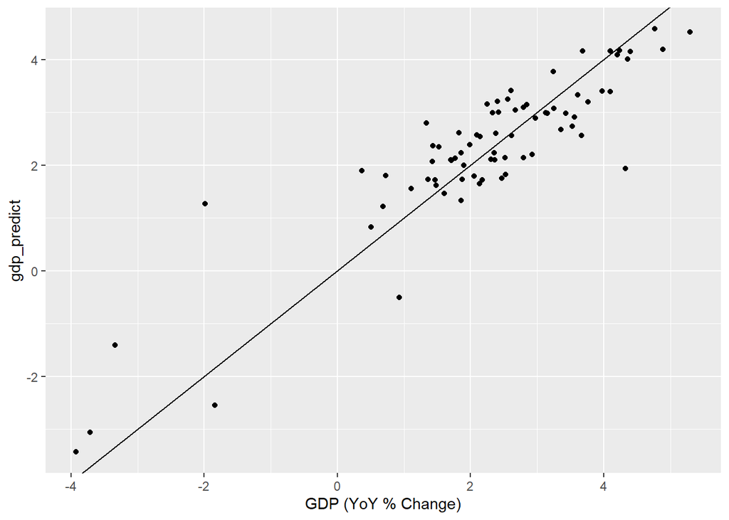

```r
stopCluster(cl)
saveRDS(gbm_recession, "./models/jolts_gbm_GDPChange.RDS")
gbm_recession <- readRDS("./models/jolts_gbm_GDPChange.RDS")
y_predict <- predict(gbm_recession, newdata = testing)
testing$gdp_predict <- y_predict
ggplot(testing, aes(x = `GDP (YoY % Change)`, y = gdp_predict)) +
  geom_point() +
  geom_abline(slope = 1)
```

```r
postResample(y_predict, obs = testing$`GDP (YoY % Change)`)
```

```
##      RMSE  Rsquared       MAE
## 0.7802179 0.8079301 0.5842642
```